# AIRSIS Data Extremes 2021

Jonathan Callahan

2022-09-08

This mini-report takes a look at the data values from temporary monitors whose data is handled by the AIRSIS (aka Oceaneering).

We compare data values from these monitors against suggested QC chcecks for:

- Max severe (invalid) range = 750 ug/m3
- Rate of change = 250 ug/m3/hr

# AIRSIS Data

During the fall of 2021, 132 monitors were deployed whose data was transmitted via satellite to AIRSIS and subsequently processed by AirFire data ingest scripts. The following plots show the values of PM2.5 for a three month period when wildfire smoke was impacting communities.

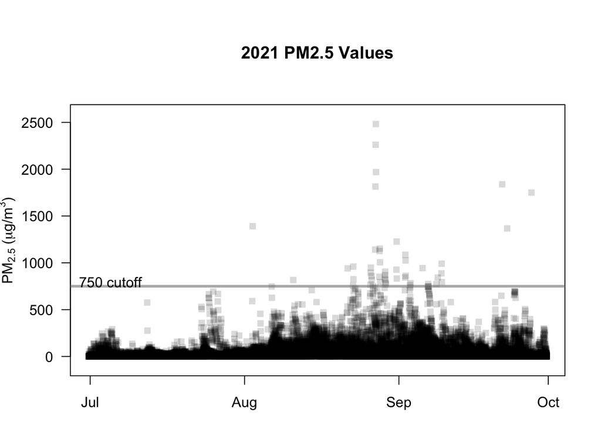

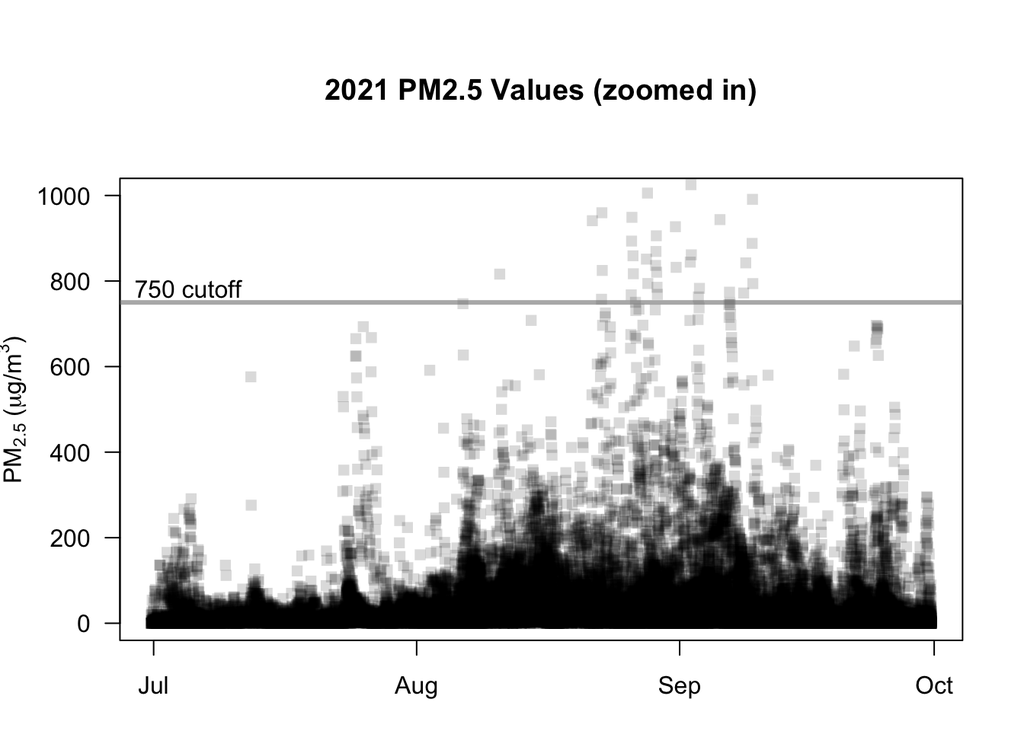

## High Value Cutoff = 750

AirNow uses automated QC to invalidate any values above a “Max Severe” level. The default level for this high value cutoff is 750 ug/m3.

Below we see two histograms, one with all of the values below the default “high value” cutoff of 750 ug/m3 and a second one with all the values above the cutoff.

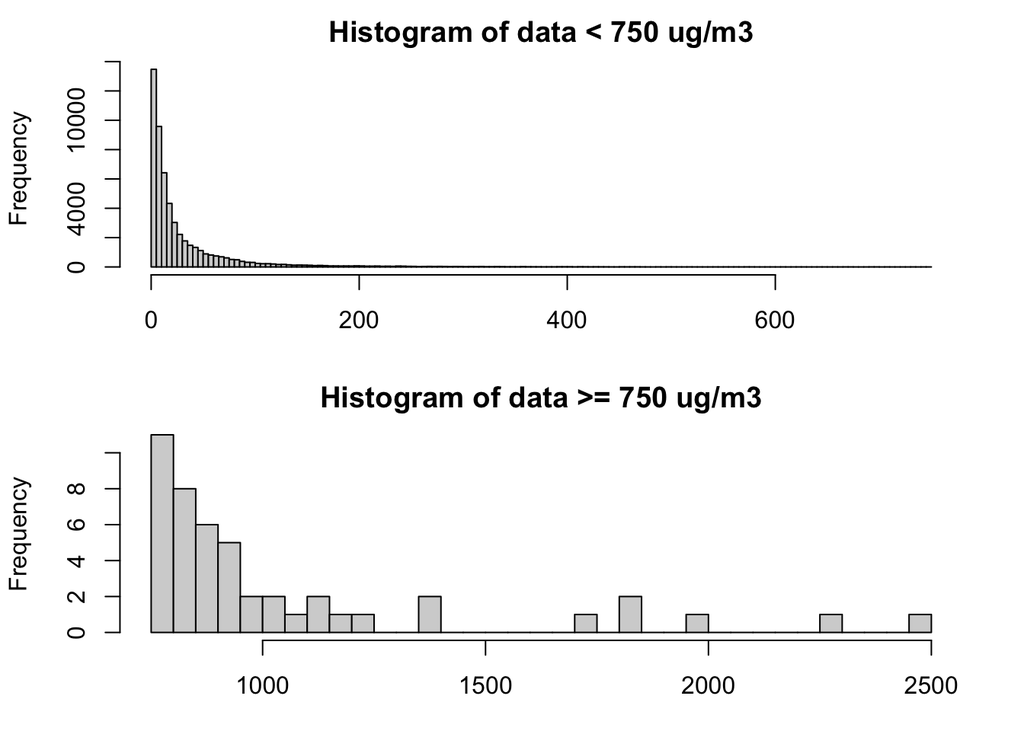

**Monitors with the highest values**

8 monitors in this time period had hourly PM2.5 values above 750 ug/m3.

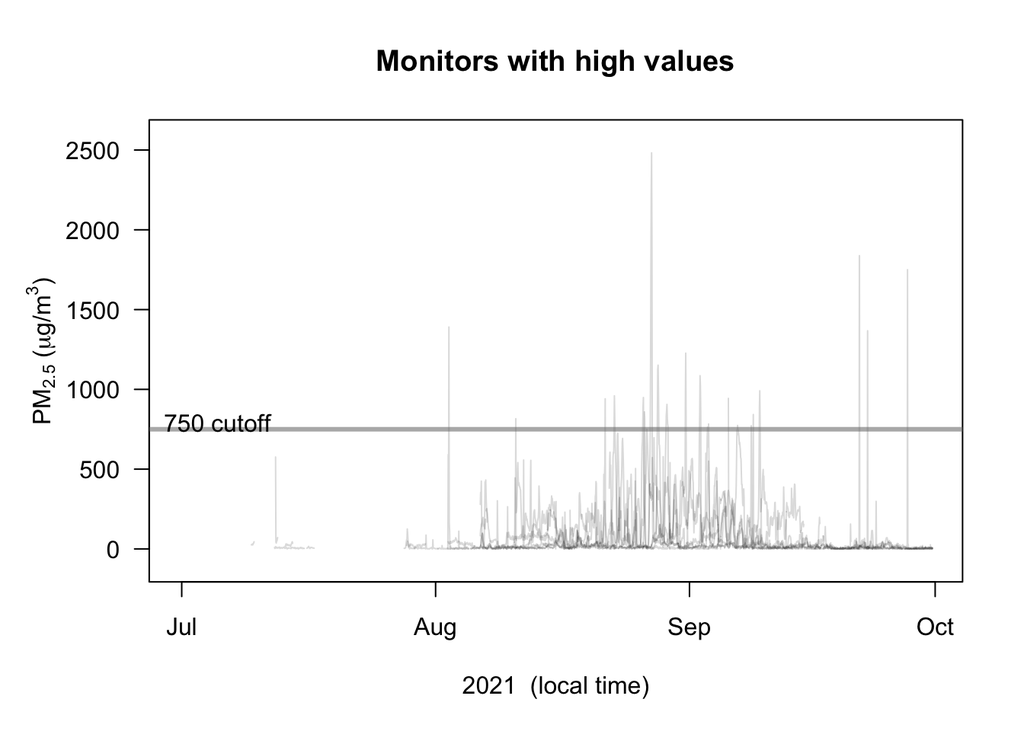

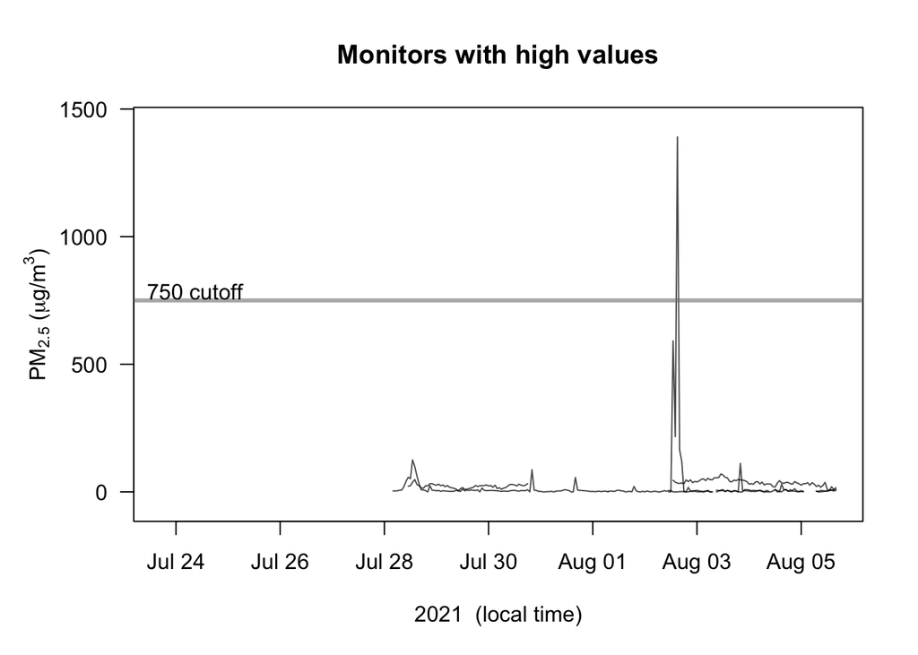

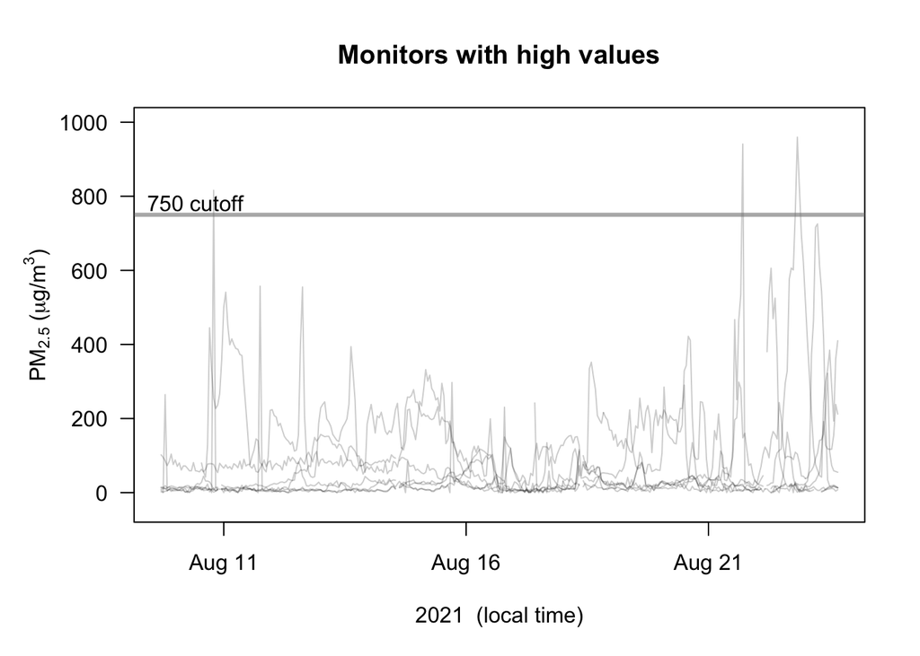

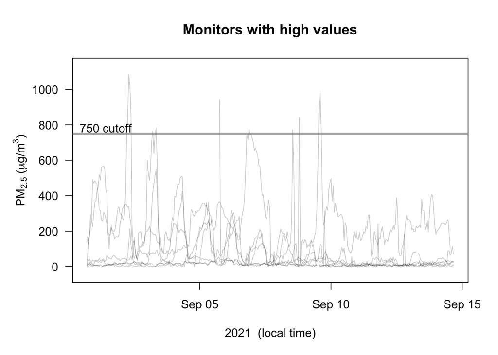

## Rate of Change Cutoff = 250 ug/m3/hr

AirNow QC also applies a rate-of-change cutoff of 250 ug/m3/hr to flag suspect data. This cutoff may also be too low for monitors deployed near wildfires.

The histograms of rate-of-change for this time period are below. There are many rate-of-change values above 250 ug/m3/hr in the monitoring data.

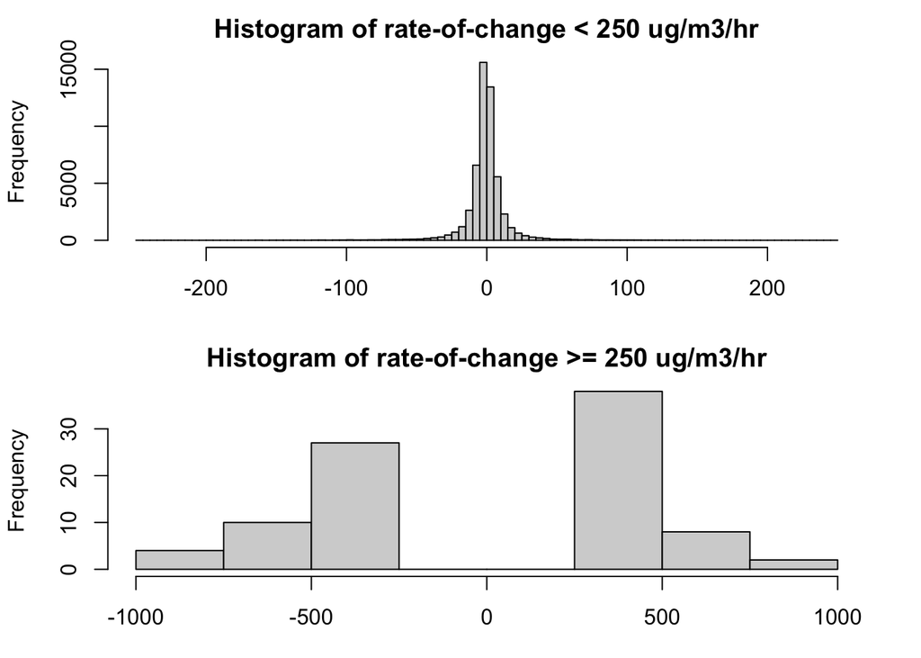

**Monitors with high rate-of-change values**

We can view those high rate-of-change values in context with the following series of timeseries plots. For the vast majority of cases, these high rate-of-change values are associated with smoke in an environment with strong diurnal variation in PM2.5 levels. All of these values in red are associated with high rate-of-change and almost all appear to be valid.

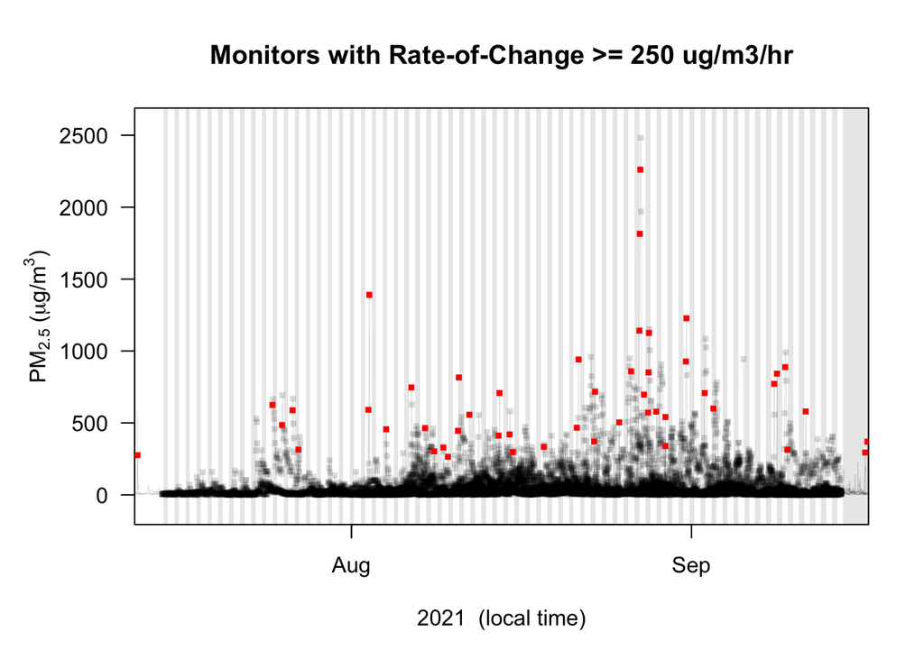

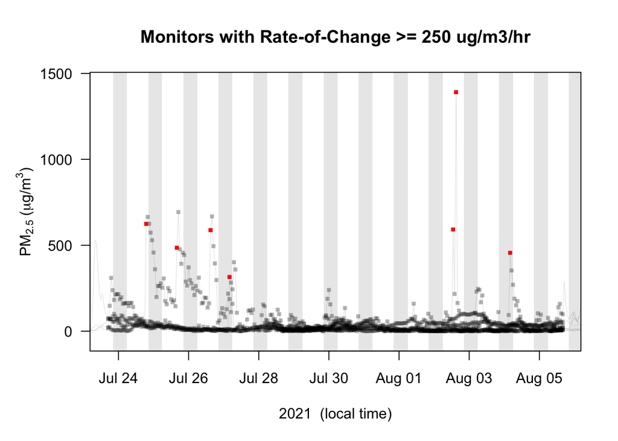

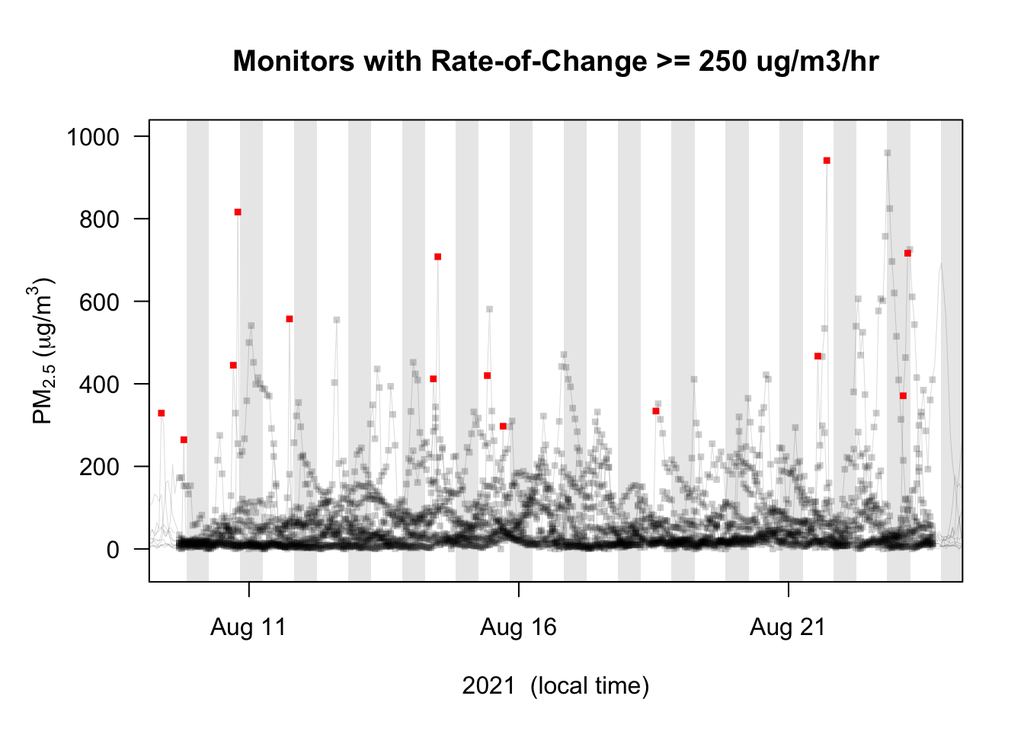

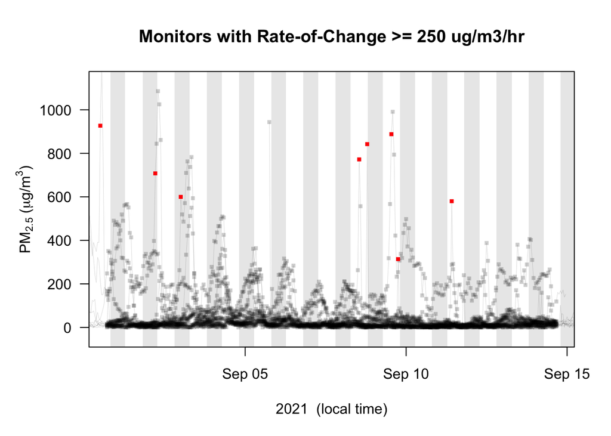